# Data Analysis of the Study “Comparison of prodigies & professional musicians”

VP

2022-01-05

This document shows the data analysis used for our paper:

> You *Can* Tell a Prodigy From a Professional Musician: A Replication of Comeau et al.’s (2017) Study

submitted for publication in *Music Psychology*. We also provide a JASP file with any other analyses.

# Dataset

*N* = 278

Levels of factor variables:

```
## $Language
## [1] "C" "D"
##
## $RatingCorrectStim01
## [1] "0" "1"
##
## $RatingCorrectStim02
## [1] "0" "1"
##
## $RatingCorrectStim03
## [1] "0" "1"
##
## $RatingCorrectStim04
## [1] "0" "1"
##
## $RatingCorrectStim05
## [1] "0" "1"
##
## $RatingCorrectStim06
## [1] "0" "1"
##
## $RatingCorrectStim07
## [1] "0" "1"
##
## $RatingCorrectStim08
## [1] "0" "1"
##
## $RatingCorrectStim09
## [1] "0" "1"
##
## $RatingCorrectStim10
## [1] "0" "1"
##
## $RatingAsProdigyStim2
## [1] "0" "1"
##
## $RatingAsProdigyStim4
## [1] "0" "1"
##
## $RatingAsProdigyStim6
```

[output cut: 41 more lines]

```
## $Gender
## [1] "female"        "male"          "diverse"       "not specified"
##
## $MusicalProfession
## [1] "Nonmusician"
## [2] "Amateur musician"
## [3] "Professional musician"
## [4] "Other (specified in the next variable)"
##
## $Pianist
## [1] "Nonmusician"              "Musician, but no pianist"
## [3] "Amateur pianist"          "Professional pianist"
##
## $PianistAndMusiciansGroups
## [1] "A" "B" "C" "D" "E"
```

# Number and Proportion of Pianists

| Piano Expertise | Proportion (in %) |
| --- | --- |
| Nonmusician | 9.7 |
| Musician, but no pianist | 21.9 |
| Amateur pianist | 56.5 |
| Professional pianist | 11.9 |

# Hits, False Alarms, and Overall Correct Responses

Contingency Table for Hits

```
##
##   0 0.2 0.4 0.6 0.8   1
##   3  39  90 102  36   8
```

Contingency Table for False Alarms

```
##
##   0 0.2 0.4 0.6 0.8   1
##  14  62 103  63  31   5
```

We had to correct proportions of Hits and False Alarms 30 times, because the proportions were 0 or 1.

Proportion of overall correct responses

|  | vars | n | mean | sd | min | max | range | se |
| --- | --- | --- | --- | --- | --- | --- | --- | --- |
| P_Hits | 1 | 278 | 51.01 | 20.28 | 0 | 100 | 100 | 1.22 |
| Misses | 2 | 278 | 48.99 | 20.28 | 0 | 100 | 100 | 1.22 |
| Correct rejections | 3 | 278 | 56.40 | 22.19 | 0 | 100 | 100 | 1.33 |
| P_FAs | 4 | 278 | 43.60 | 22.19 | 0 | 100 | 100 | 1.33 |
| Overall_correct_responses | 5 | 278 | 53.71 | 15.04 | 10 | 90 | 80 | 0.90 |

The confidence interval of P_Hits, P_FAs, and overall correct responses are:

```
##   95% CI for Proportion in % for Lower Upper
## 1                         P_Hits 48.61 53.40
## 2                         Misses 46.60 51.39
## 3             Correct_rejections 53.78 59.02
## 4                          P_FAs 40.98 46.22
## 5      Overall_correct_responses 51.93 55.48
```

```
## $P_Hits
## lower upper
## 48.61 53.40
##
## $P_FAs
## lower upper
## 40.98 46.22
##
## $Overall_correct_responses
## lower upper
## 51.93 55.48
```

```
## # A tibble: 5 x 6
##   Proportion                    M    SD    SE CI_LL CI_UL
##   <chr>                     <dbl> <dbl> <dbl> <dbl> <dbl>
## 1 P_Hits                     51.0  20.3  1.22  48.6  53.4
## 2 Misses                     49.0  20.3  1.22  46.6  51.4
## 3 Correct_rejections         56.4  22.2  1.33  53.8  59.0
## 4 P_FAs                      43.6  22.2  1.33  41.0  46.2
## 5 Overall_correct_responses  53.7  15.0  0.9   52.0  55.5
```

| Level of Expertise | n | % | M (Sensitivity d’) | SD (Sensitivity d’) | SE (Sensitivity d’) | LL (Sensitivity d’) | UL (Sensitivity d’) | M (% correct) | SD (% correct) | SE (% correct) |
| --- | --- | --- | --- | --- | --- | --- | --- | --- | --- | --- |
| Professional pianists | 33 | 11.9 | 0.31 | 0.98 | 0.17 | -0.032 | 0.660 | 55.76 | 18.03 | 3.1391438 |
| Other professional musicians | 30 | 10.8 | 0.30 | 0.79 | 0.14 | 0.006 | 0.592 | 55.67 | 14.55 | 2.6558689 |
| Amateur pianists | 118 | 42.4 | 0.18 | 0.82 | 0.08 | 0.032 | 0.331 | 53.47 | 15.27 | 1.4055679 |
| Other amateur musicians | 46 | 16.5 | 0.15 | 0.79 | 0.12 | -0.086 | 0.382 | 52.83 | 14.40 | 2.1233244 |
| Nonmusicians | 51 | 18.3 | 0.14 | 0.74 | 0.10 | -0.070 | 0.349 | 52.55 | 13.54 | 1.8961910 |
| Overall | 278 | 100.0 | 0.20 | 0.81 | 0.05 | 0.100 | 0.293 | 53.71 | 15.04 | 0.9022262 |
| Musicians | 227 | 81.7 | 0.21 | 0.83 | 0.06 | 0.101 | 0.318 | 53.96 | 15.38 | 1.0205456 |
| Nonmusicians (Hypothesis B) | 51 | 18.3 | 0.14 | 0.74 | 0.10 | -0.070 | 0.349 | 52.55 | 13.54 | 1.8961910 |
| Pianists | 33 | 11.9 | 0.31 | 0.98 | 0.17 | -0.032 | 0.660 | 55.76 | 18.03 | 3.1391438 |
| Other | 245 | 88.1 | 0.18 | 0.79 | 0.05 | 0.081 | 0.280 | 53.43 | 14.62 | 0.9337363 |

# Sensitivity *d’*

## Descriptive Statistics

|  | vars | n | mean | sd | median | trimmed | mad | min | max | range | skew | kurtosis | se |
| --- | --- | --- | --- | --- | --- | --- | --- | --- | --- | --- | --- | --- | --- |
| X1 | 1 | 278 | 0.197 | 0.815 | 0 | 0.233 | 0.872 | -2.123 | 2.123 | 4.246 | -0.272 | -0.152 | 0.049 |

## Sensitivity *d’* of Different Groups

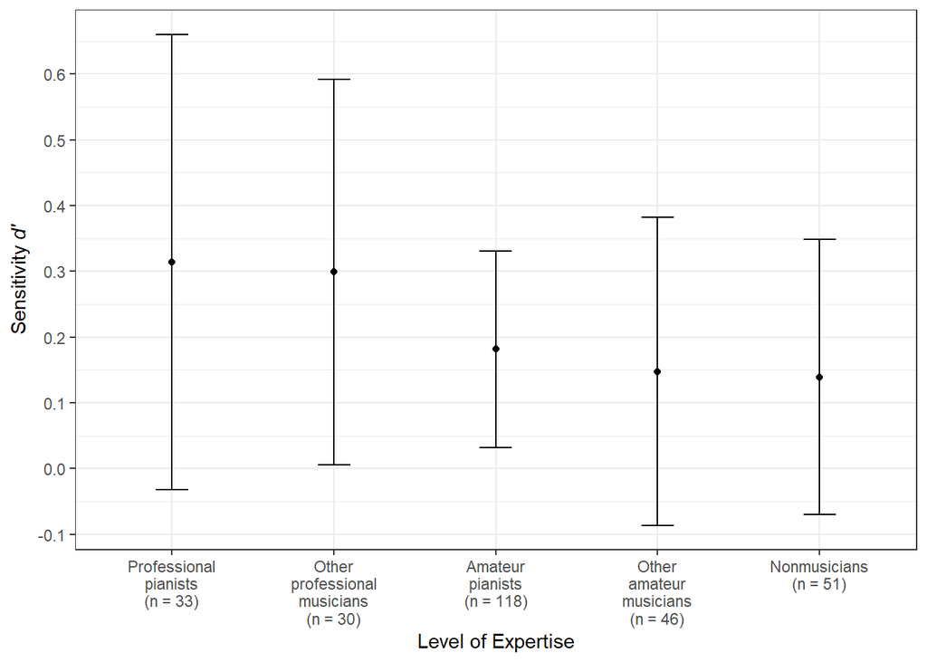

## T-test and Cohens’d

```
##
##  One Sample t-test
##
## data:  DATA_prtcpnt$Sensitivity_d
## t = 4.0241, df = 277, p-value = 7.385e-05
## alternative hypothesis: true mean is not equal to 0
## 95 percent confidence interval:
##  0.1004732 0.2929165
## sample estimates:
## mean of x
## 0.1966948
```

```
##
## Cohen's d (single sample)
##
## d estimate: 0.2413501 (small)
## Reference mu: 0
## 95 percent confidence interval:
##       lower       upper
## 0.004358653 0.478341619
```

# Bias *c*

## Descriptive Statistics

|  | vars | n | mean | sd | median | trimmed | mad | min | max | range | skew | kurtosis | se |
| --- | --- | --- | --- | --- | --- | --- | --- | --- | --- | --- | --- | --- | --- |
| X1 | 1 | 278 | 0.073 | 0.405 | 0 | 0.084 | 0.406 | -1.062 | 1.282 | 2.343 | -0.148 | 0.235 | 0.024 |

# AUC and ROC for Each Participant

## Calculation of ROC and AUC

We plot the receiver operating characteristic (ROC) curve of every twentieth participant.

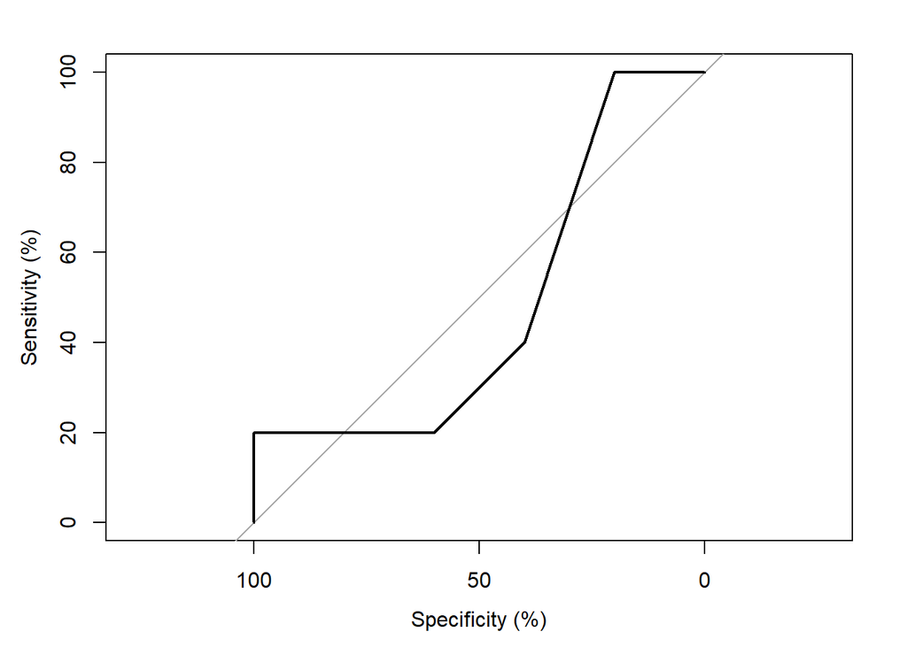

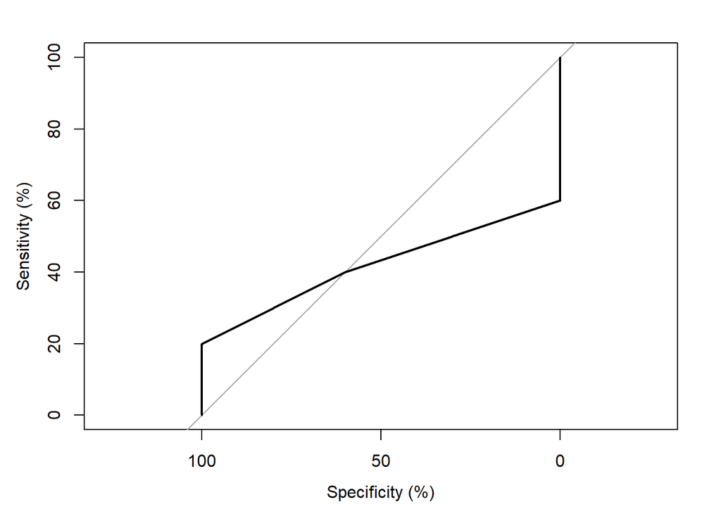

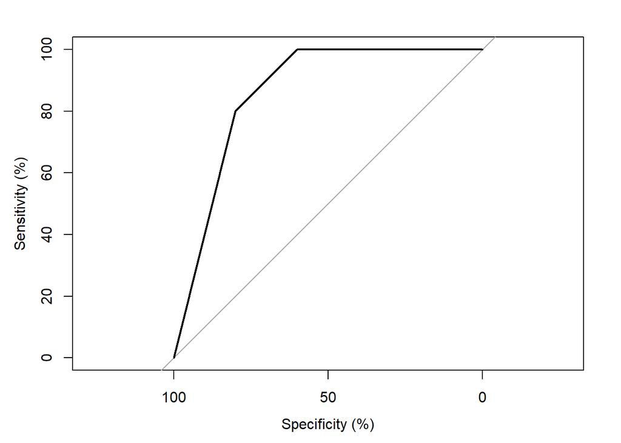

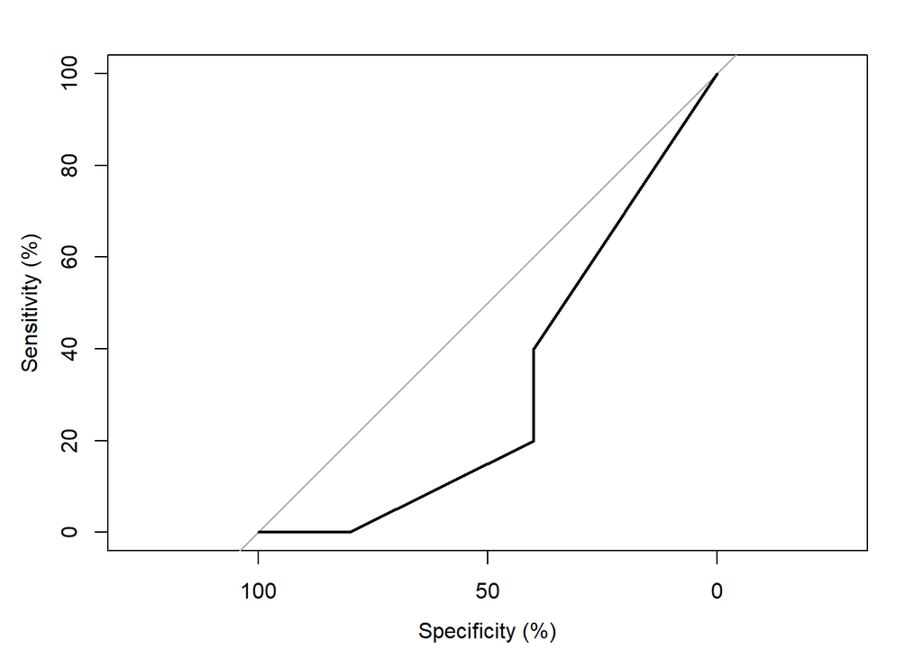

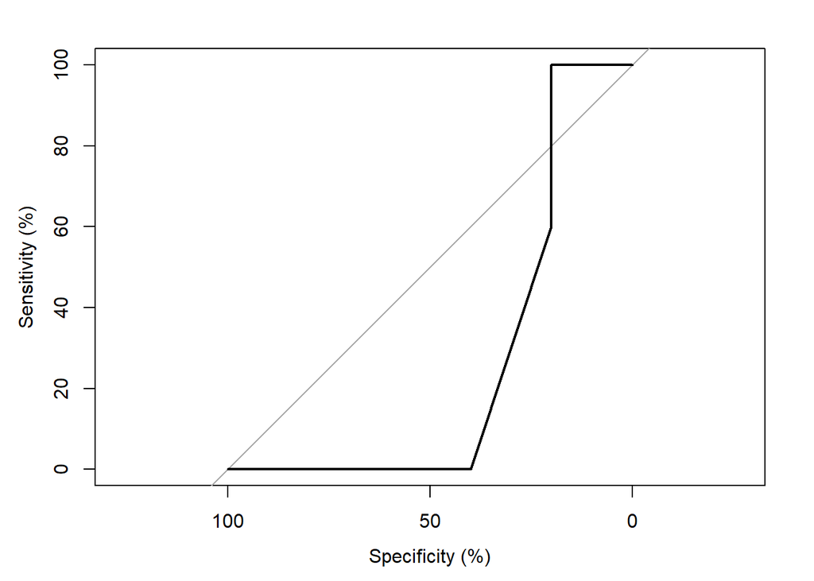

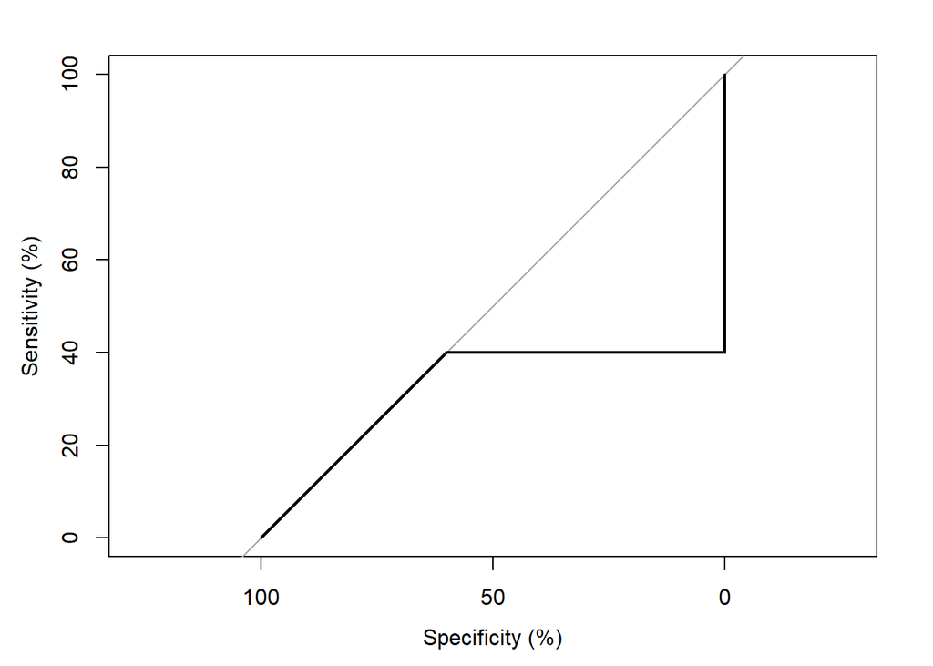

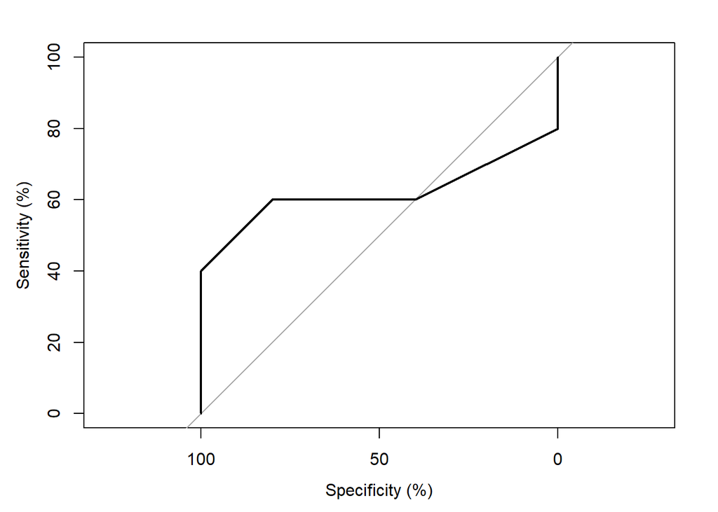

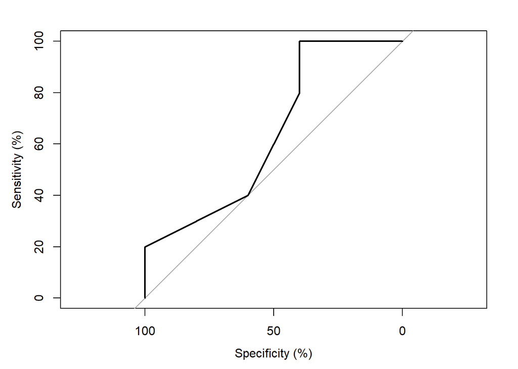

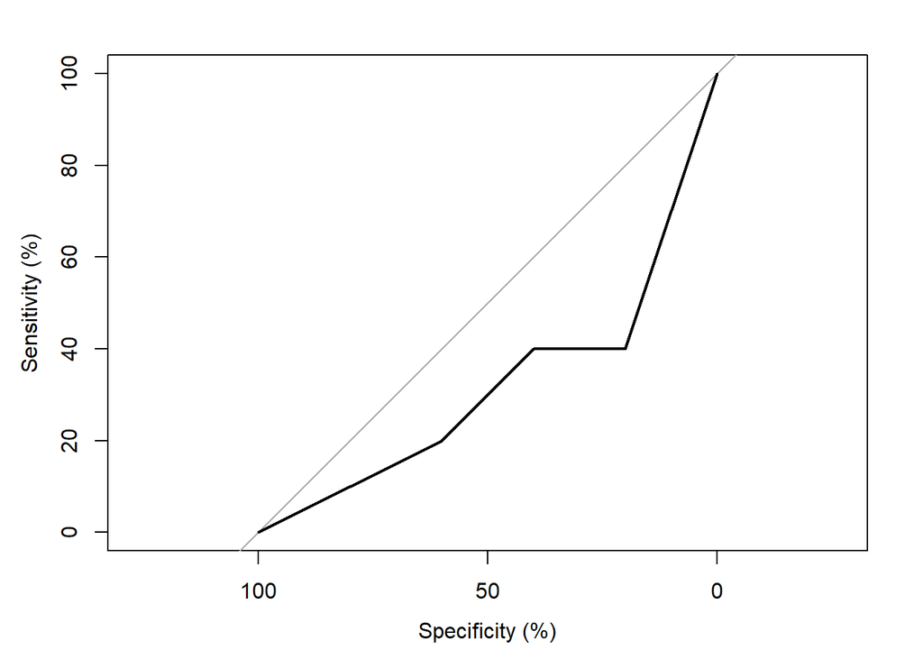

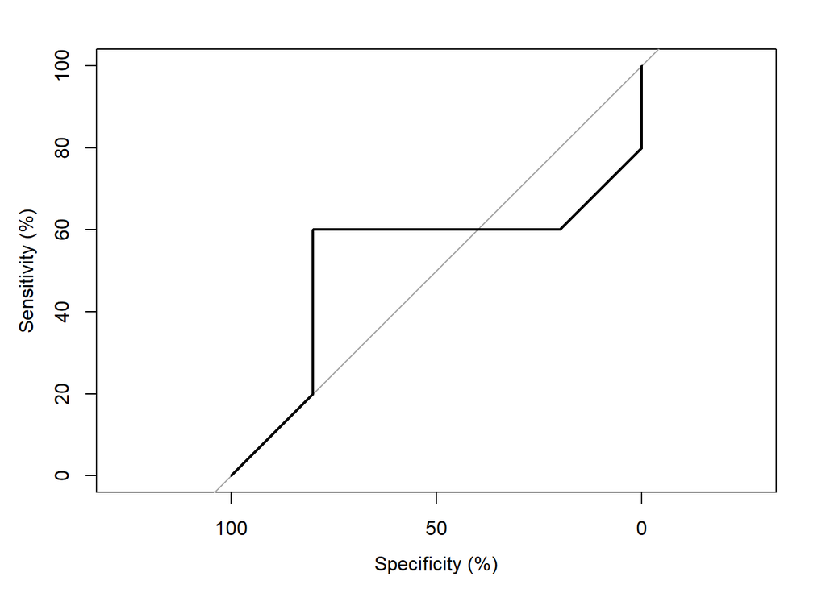

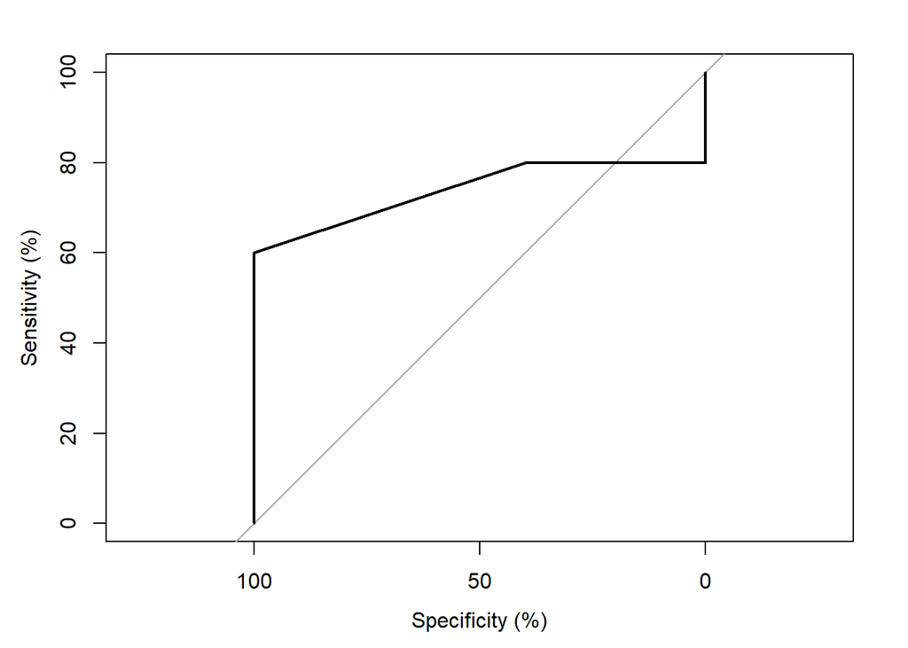

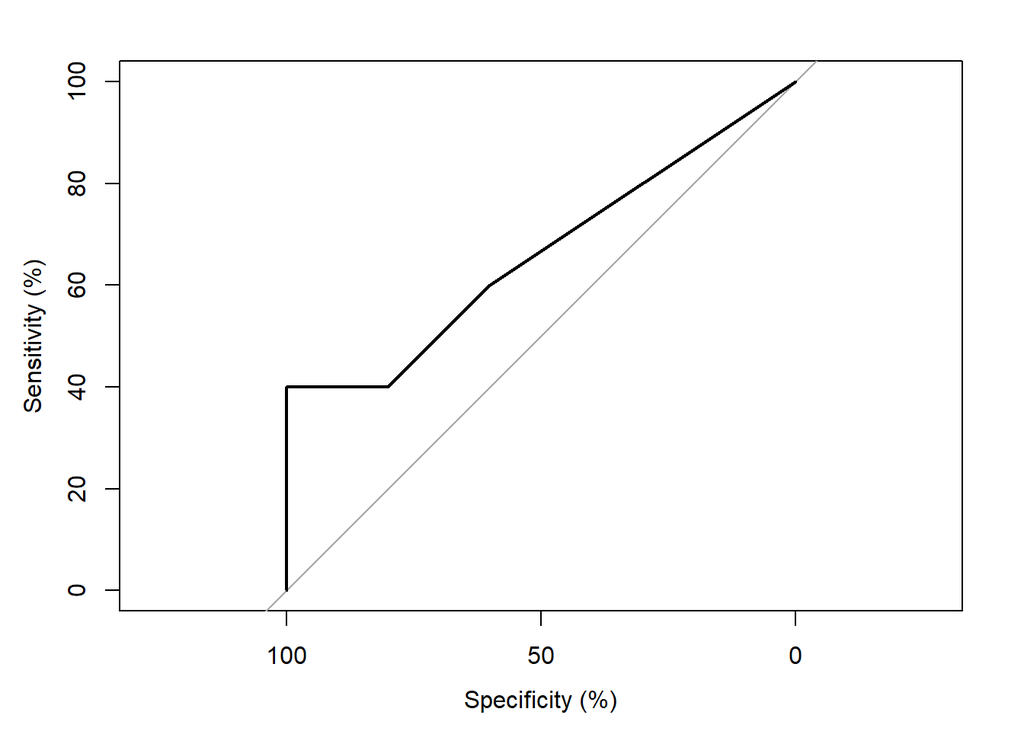

[1 more figures not shown]

## Descriptive Statistics of AUC

|  | vars | n | mean | sd | median | trimmed | mad | min | max | range | skew | kurtosis | se |
| --- | --- | --- | --- | --- | --- | --- | --- | --- | --- | --- | --- | --- | --- |
| X1 | 1 | 278 | 0.54 | 0.18 | 0.54 | 0.54 | 0.18 | 0 | 0.96 | 0.96 | -0.176 | -0.2 | 0.011 |

The confidence interval of AUC is: [0.51, 0.56].

## t-Test and Cohen’s d

Is Mean AUC (0.535) significantly greater than chance level (0.5)? How large is this effect?

```
##
##  One Sample t-test
##
## data:  DATA_prtcpnt$AUC
## t = 3.3377, df = 277, p-value = 0.0004802
## alternative hypothesis: true mean is greater than 0.5
## 95 percent confidence interval:
##  0.5179302       Inf
## sample estimates:
## mean of x
## 0.5354676
```

```
##
## Cohen's d (single sample)
##
## d estimate: 0.200182 (small)
## Reference mu: 0.5
## 95 percent confidence interval:
##       lower       upper
## -0.03654205  0.43690603
```

# Histograms of Sensitivity *d’*, Bias *c* and AUC:

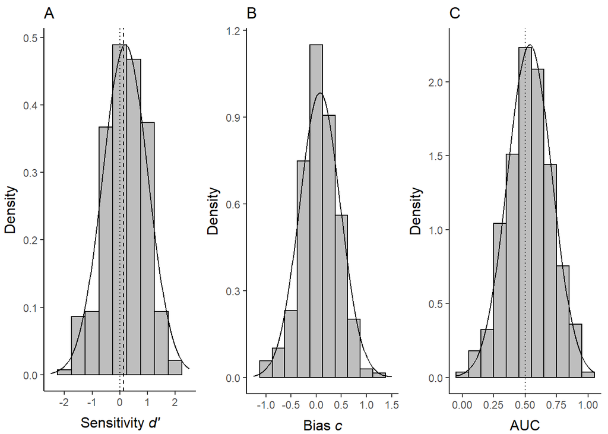

# Musical Culture: German (D) and Traditional Chinese (C)

## Musical Culture and Categorization of Musicianship

Proportions of each group per language (in %)

| Expertise | C | D |
| --- | --- | --- |
| Professional pianists | 5.5 | 16.1 |
| Other professional musicians | 4.5 | 14.9 |
| Amateur pianists | 52.7 | 35.7 |
| Other amateur musicians | 9.1 | 21.4 |
| Nonmusicians | 28.2 | 11.9 |
| Total | 100.0 | 100.0 |

## Musical Culture and Classification Performance

Descriptive statistics

```
##
## =========================================================
## Statistic                  N  Mean  St. Dev.  Min    Max
## ---------------------------------------------------------
## Sensitivity_d             110 0.186  0.793   -2.123 1.683
## AUC                       110 0.517  0.174   0.000  0.960
## Quiz_Score                110 2.773  2.241     0      6
## Overall_correct_responses 110 0.535  0.147   0.100  0.800
## ---------------------------------------------------------
##
## =========================================================
## Statistic                  N  Mean  St. Dev.  Min    Max
## ---------------------------------------------------------
## Sensitivity_d             168 0.204  0.831   -1.683 2.123
## AUC                       168 0.548  0.179   0.100  0.920
## Quiz_Score                168 2.720  2.240     0      6
## Overall_correct_responses 168 0.538  0.153   0.200  0.900
## ---------------------------------------------------------
```

Does a difference exist between the two different sub-samples, i.e. the German (D) and Traditional Chinese (C) speaking participants? How large is the effect (Cohen’s *d*)?

```
## $Sensitivity_d
## Levene's Test for Homogeneity of Variance (center = median)
##        Df F value Pr(>F)
## group   1  0.0967 0.7561
##       276
##
## $AUC
## Levene's Test for Homogeneity of Variance (center = median)
##        Df F value Pr(>F)
## group   1  0.5126 0.4746
##       276
##
## $Quiz_Score
## Levene's Test for Homogeneity of Variance (center = median)
##        Df F value Pr(>F)
## group   1   0.078 0.7803
##       276
##
## $Overall_correct_responses
## Levene's Test for Homogeneity of Variance (center = median)
##        Df F value Pr(>F)
## group   1  0.1063 0.7446
##       276
##
## $GoldMSI_Score
## Levene's Test for Homogeneity of Variance (center = median)
##        Df F value Pr(>F)
## group   1  2.4429 0.1192
##       276
```

| variable | n C | n D | Mean Difference | Mean C | Mean D | SD C | SD D | t | p | df | Method | Effect size | Magnitude |
| --- | --- | --- | --- | --- | --- | --- | --- | --- | --- | --- | --- | --- | --- |
| Sensitivity_d | 110 | 168 | -0.017 | 0.186 | 0.204 | 0.793 | 0.831 | -0.17 | 0.862 | 241 | Welch Two Sample t-test | -0.021 | negligible |
| AUC | 110 | 168 | -0.031 | 0.517 | 0.548 | 0.174 | 0.179 | -1.43 | 0.155 | 238 | Welch Two Sample t-test | -0.174 | negligible |
| GoldMSI_Score | 110 | 168 | -10.645 | 80.045 | 90.690 | 17.858 | 19.886 | -4.64 | 0.000 | 250 | Welch Two Sample t-test | -0.563 | moderate |
| Overall_correct_responses | 110 | 168 | -0.003 | 0.535 | 0.538 | 0.147 | 0.153 | -0.14 | 0.886 | 240 | Welch Two Sample t-test | -0.018 | negligible |
| Quiz_Score | 110 | 168 | 0.052 | 2.773 | 2.720 | 2.241 | 2.240 | 0.19 | 0.849 | 233 | Welch Two Sample t-test | 0.023 | negligible |

# Analysis of Gold-MSI Subscale Perceptual Abilities

We collected data for the general factor of the Gold-MSI, which only comprises two items of the perceptual abilities subscale: Items MS11_12 (“Ich kann zwei Interpretationen oder Versionen desselben Musikstücks miteinander vergleichen und über die Unterschiede diskutieren.”) and MS11_23 (“Wenn ich singe, habe ich keine Ahnung, ob ich richtig oder falsch singe.” (reversed).

Is there a correlation (in the figures below: *R*) between Perceptual Abilities and Sensitivity *d’* or between Perceptual Abilities and AUC?

```
##
##  Pearson's product-moment correlation
##
## data:  DATA_prtcpnt$GMSI_PA_mean and DATA_prtcpnt$Sensitivity_d
## t = 0.61849, df = 276, p-value = 0.5368
## alternative hypothesis: true correlation is not equal to 0
## 95 percent confidence interval:
##  -0.08079356  0.15417129
## sample estimates:
##        cor
## 0.03720305
```

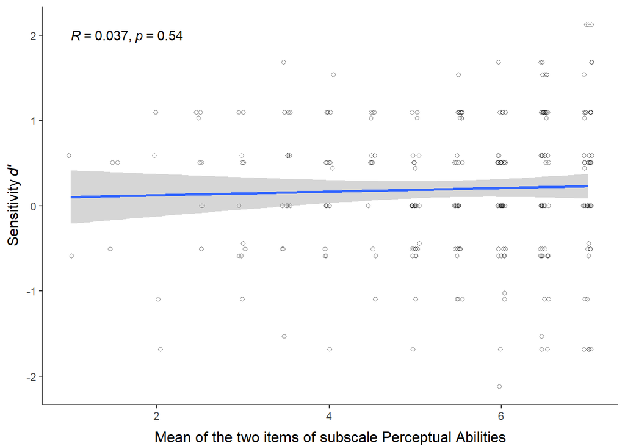

```
##
##  Pearson's product-moment correlation
##
## data:  DATA_prtcpnt$GMSI_PA_mean and DATA_prtcpnt$AUC
## t = 0.88501, df = 276, p-value = 0.3769
## alternative hypothesis: true correlation is not equal to 0
## 95 percent confidence interval:
##  -0.06485277  0.16977661
## sample estimates:
##        cor
## 0.05319609
```

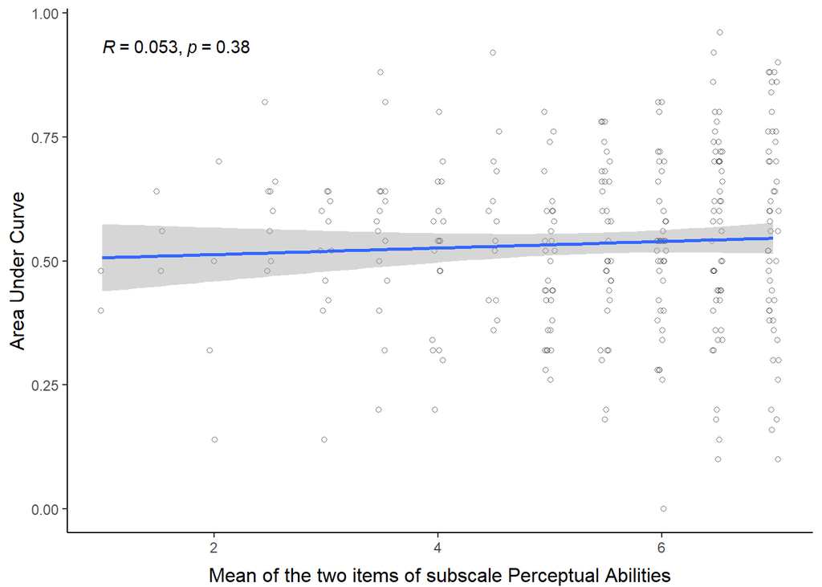

# Analysis of the Stimuli

## Musical and Acoustic Features

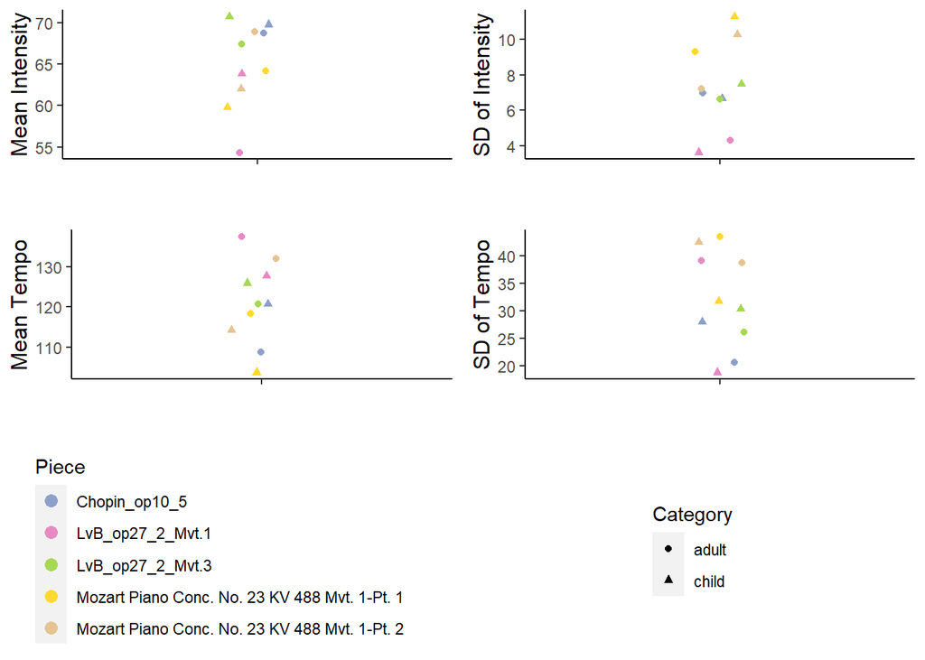

## Musical Features and Overall Correct Responses

Is there a relation between musical features and overall correct responses?

```
## Intensity_Mean_dB
##
##  Pearson's product-moment correlation
##
## data:  DATA_stimuli[[x_var]] and DATA_stimuli[, c(Overall_correct_responses)]
## t = -0.40176, df = 8, p-value = 0.6984
## alternative hypothesis: true correlation is not equal to 0
## 95 percent confidence interval:
##  -0.7076037  0.5364981
## sample estimates:
##        cor
## -0.1406331
##
## Intensity_SD_dB
##
##  Pearson's product-moment correlation
##
## data:  DATA_stimuli[[x_var]] and DATA_stimuli[, c(Overall_correct_responses)]
## t = -3.0412, df = 8, p-value = 0.01603
## alternative hypothesis: true correlation is not equal to 0
## 95 percent confidence interval:
##  -0.9321283 -0.1904324
## sample estimates:
##        cor
## -0.7322598
##
## Tempo_Mean
##
##  Pearson's product-moment correlation
##
## data:  DATA_stimuli[[x_var]] and DATA_stimuli[, c(Overall_correct_responses)]
## t = 1.8975, df = 8, p-value = 0.09433
## alternative hypothesis: true correlation is not equal to 0
## 95 percent confidence interval:
##  -0.1116934  0.8785627
## sample estimates:
##       cor
## 0.5571119
##
## Tempo_SD
##
##  Pearson's product-moment correlation
##
## data:  DATA_stimuli[[x_var]] and DATA_stimuli[, c(Overall_correct_responses)]
## t = -0.65447, df = 8, p-value = 0.5312
## alternative hypothesis: true correlation is not equal to 0
## 95 percent confidence interval:
##  -0.7487795  0.4710526
## sample estimates:
##        cor
## -0.2254348
```

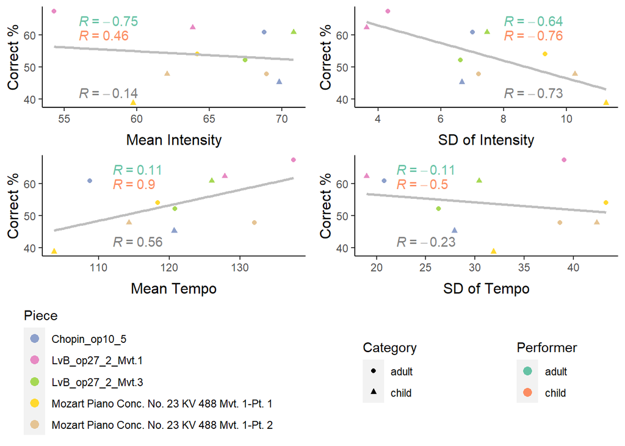

## Musical Features and Classification

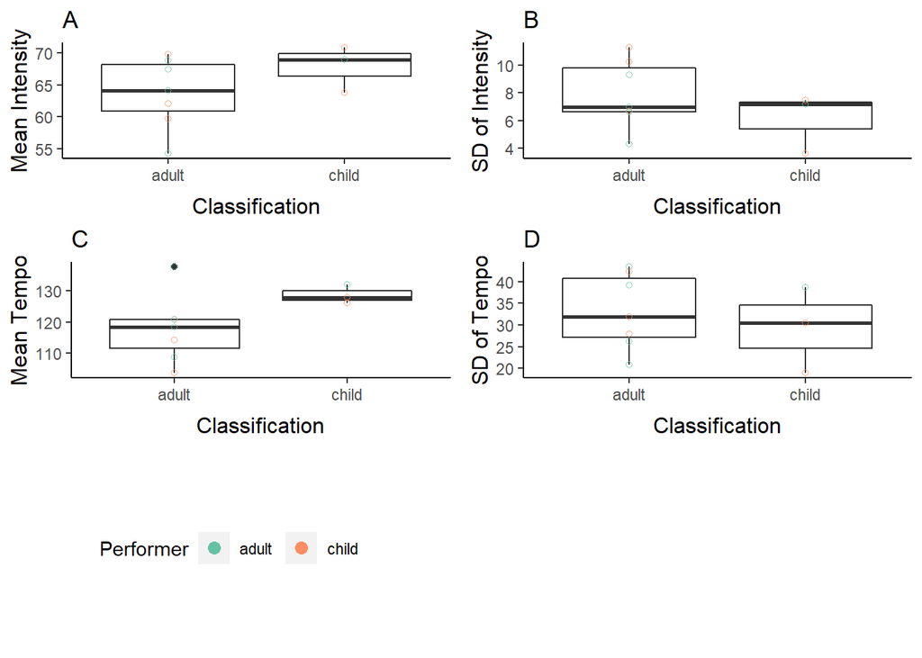

## Regression

### Per Item

The variance of the overall correct response proportion is 80.3, the mean is 53.7. We conducted a regression analysis to predict participant accuracy as measured by the overall percentage of correct responses using the acoustic features of the stimuli.

```
##
## Call:
## lm(formula = formula, data = DATA_stimuli)
##
## Residuals:
##       1       2       3       4       5       6       7       8       9      10
## -9.9956  5.5903 -0.6001  1.9293 10.5296 -2.4547 -3.0875  3.1072  0.3063 -5.3247
##
## Coefficients:
##                     Estimate Std. Error t value Pr(>|t|)
## (Intercept)       126.922864  93.976108   1.351    0.235
## Intensity_Mean_dB  -0.006654   0.640883  -0.010    0.992
## Intensity_SD_dB    -4.955075   4.147503  -1.195    0.286
## Tempo_Mean         -0.431773   0.836513  -0.516    0.628
## Tempo_SD            0.499565   0.849578   0.588    0.582
##
## Residual standard error: 7.743 on 5 degrees of freedom
## Multiple R-squared:  0.5851, Adjusted R-squared:  0.2532
## F-statistic: 1.763 on 4 and 5 DF,  p-value: 0.2731
```

```
##
## Call:
## lm(formula = formula, data = DATA_stimuli)
##
## Standardized Coefficients::
##       (Intercept) Intensity_Mean_dB   Intensity_SD_dB        Tempo_Mean
##       0.000000000      -0.003873245      -1.328051408      -0.500603094
##          Tempo_SD
##       0.483576932
```

$R^2$ is 0.585. The following plot shows the predicted values of the overall correct proportions:

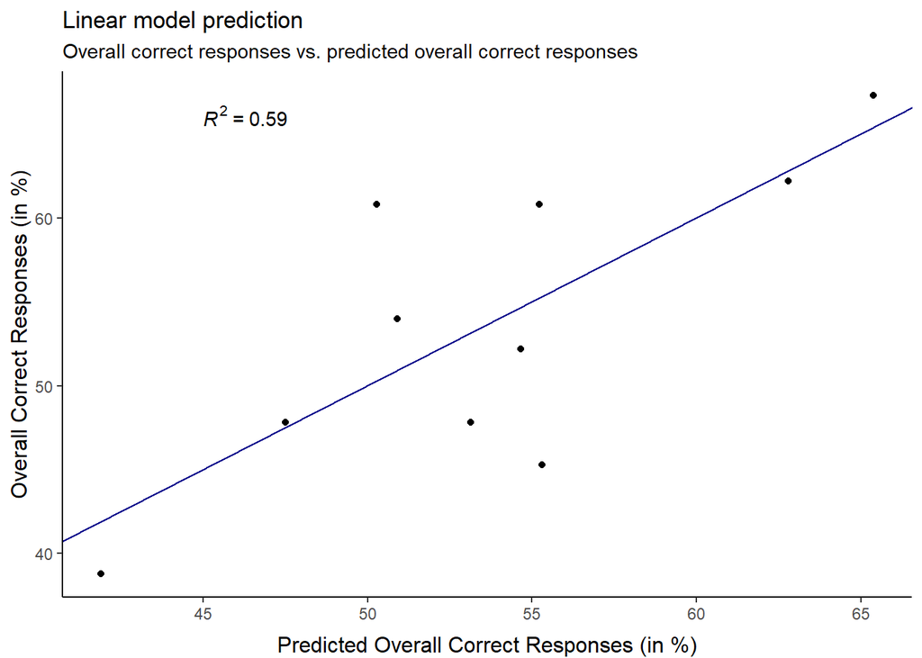

### Per Item Pair

Regression not possible, because *df* = 0.

#### Avg. Overall Correct Responses ~ Avg. Acoustic Feature, and Diff. Overall Correct Responses ~ Diff. Acoustic Feature

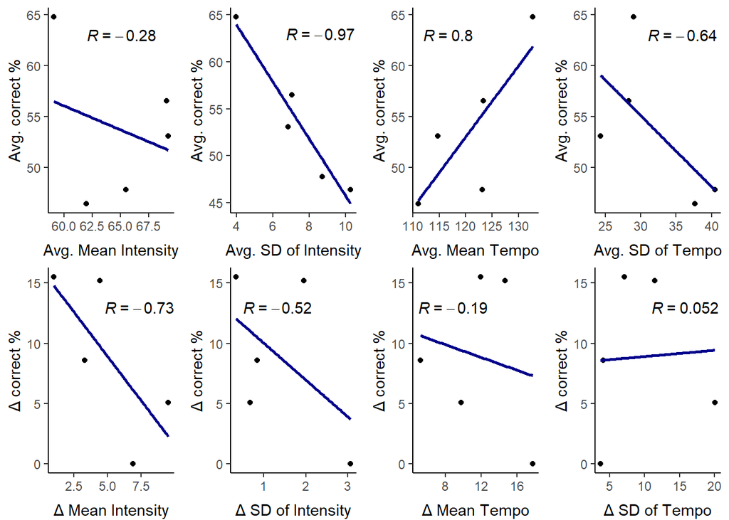

#### Avg. Overall Correct Responses ~ Diff. Acoustic Feature

```
## diff_Intensity_Mean_dB
##
##  Pearson's product-moment correlation
##
## data:  DATA_stimuli_pairs[[x_var]] and DATA_stimuli_pairs[, c(mean_Overall_correct_responses)]
## t = 0.81106, df = 3, p-value = 0.4767
## alternative hypothesis: true correlation is not equal to 0
## 95 percent confidence interval:
##  -0.7321067  0.9506563
## sample estimates:
##      cor
## 0.424076
##
## diff_Intensity_SD_dB
##
##  Pearson's product-moment correlation
##
## data:  DATA_stimuli_pairs[[x_var]] and DATA_stimuli_pairs[, c(mean_Overall_correct_responses)]
## t = -1.6343, df = 3, p-value = 0.2007
## alternative hypothesis: true correlation is not equal to 0
## 95 percent confidence interval:
##  -0.9769949  0.4967627
## sample estimates:
##       cor
## -0.686288
##
## diff_Tempo_Mean
##
##  Pearson's product-moment correlation
##
## data:  DATA_stimuli_pairs[[x_var]] and DATA_stimuli_pairs[, c(mean_Overall_correct_responses)]
## t = -1.648, df = 3, p-value = 0.1979
## alternative hypothesis: true correlation is not equal to 0
## 95 percent confidence interval:
##  -0.9772549  0.4924207
## sample estimates:
##        cor
## -0.6893169
##
## diff_Tempo_SD
##
##  Pearson's product-moment correlation
##
## data:  DATA_stimuli_pairs[[x_var]] and DATA_stimuli_pairs[, c(mean_Overall_correct_responses)]
## t = 1.3561, df = 3, p-value = 0.2681
## alternative hypothesis: true correlation is not equal to 0
## 95 percent confidence interval:
##  -0.5827527  0.9707524
## sample estimates:
##      cor
## 0.616465
```

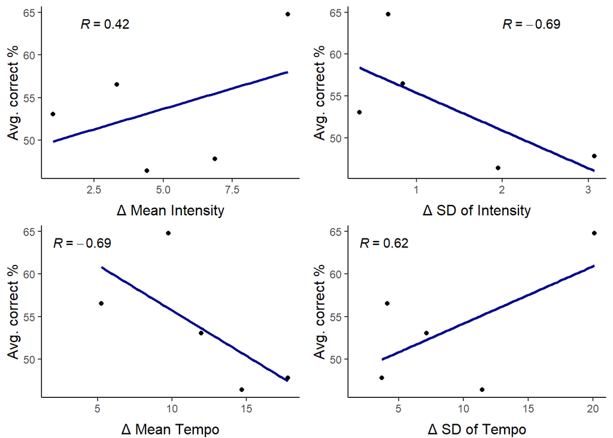

## AUC on Item Level (per Pair)

AUC for the five item pairs

```
## [1] "RatingStim01"
```

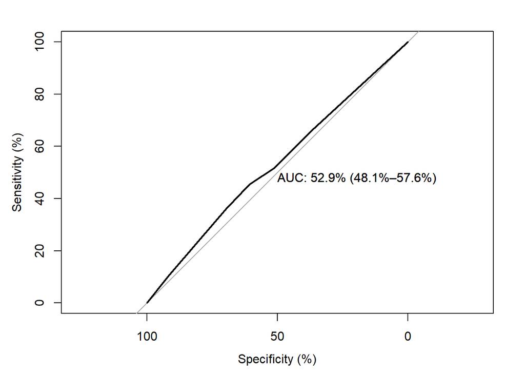

```
## [1] "RatingStim03"
```

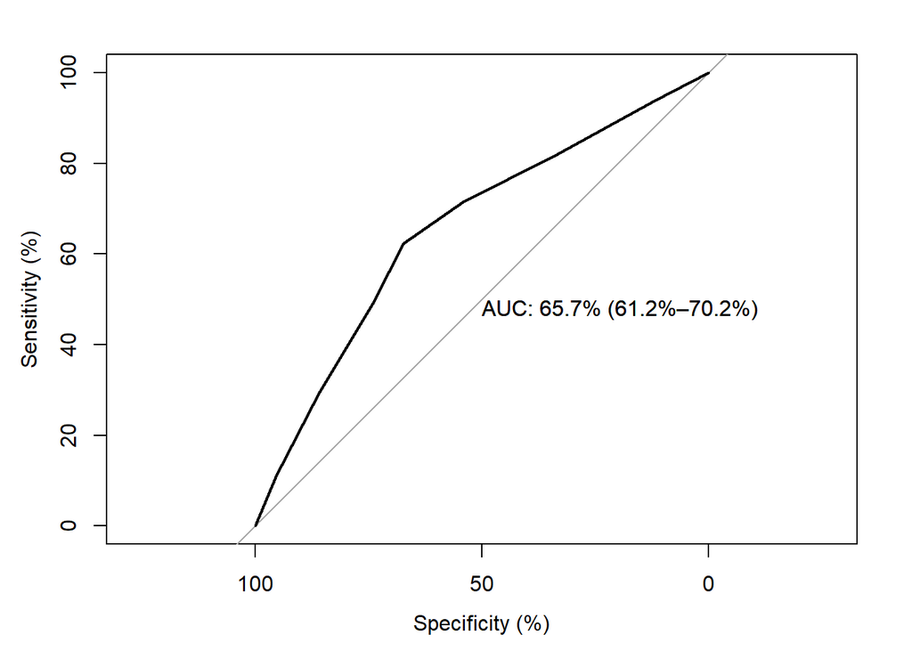

```
## [1] "RatingStim05"
```

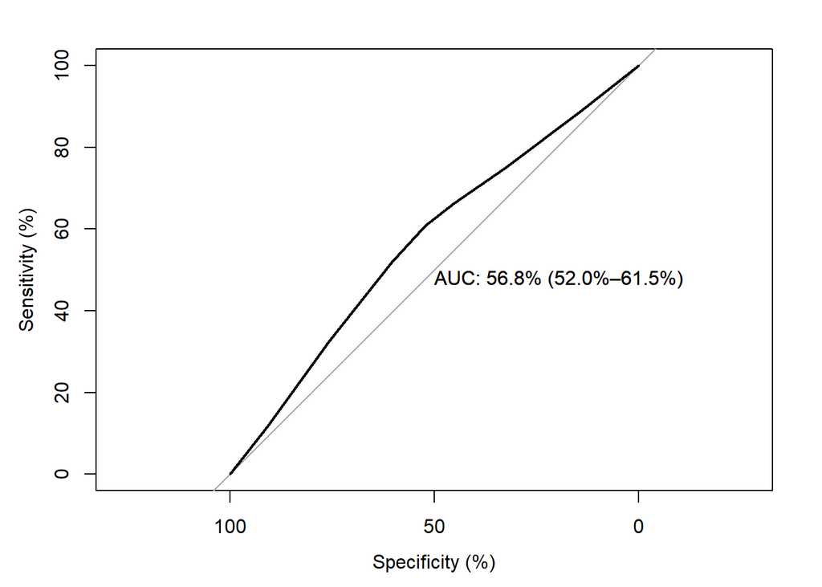

```
## [1] "RatingStim07"
```

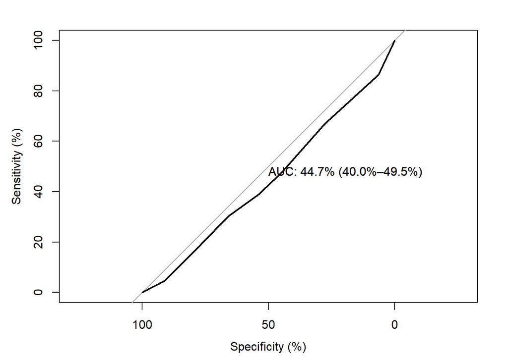

```
## [1] "RatingStim09"
```

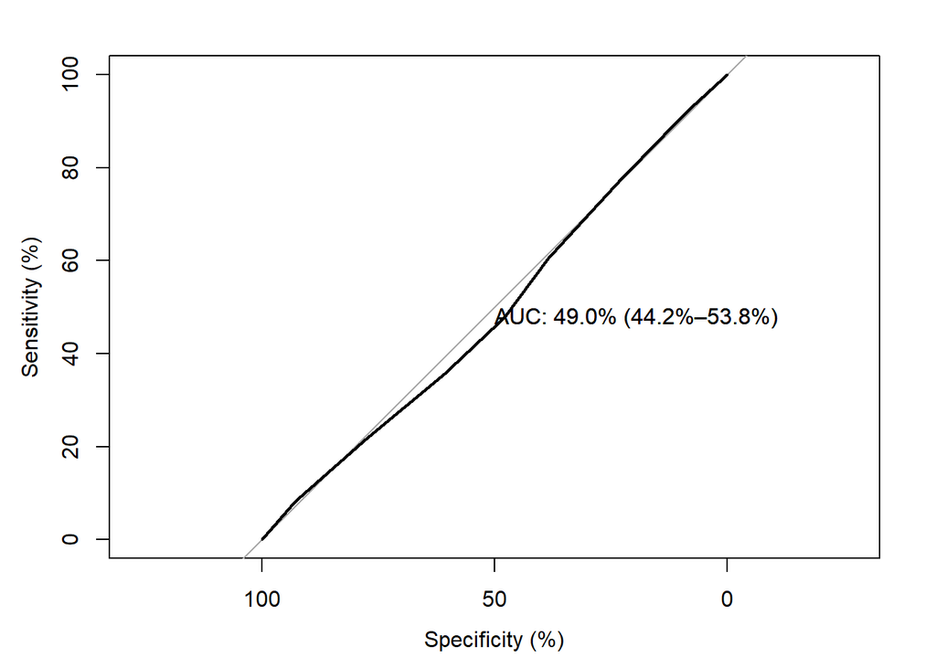

The AUC values for each item pair are:

| Piece | AUC |
| --- | --- |
| Chopin_op10_5 | 0.53 |
| LvB_op27_2_Mvt.1 | 0.66 |
| LvB_op27_2_Mvt.3 | 0.57 |
| Mozart Piano Conc. No. 23 KV 488 Mvt. 1-Pt. 1 | 0.45 |
| Mozart Piano Conc. No. 23 KV 488 Mvt. 1-Pt. 2 | 0.49 |

Manually plotting the AUC

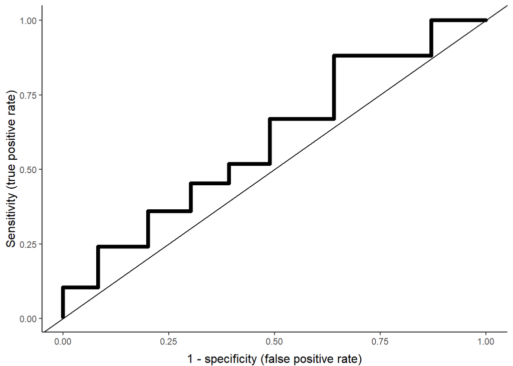

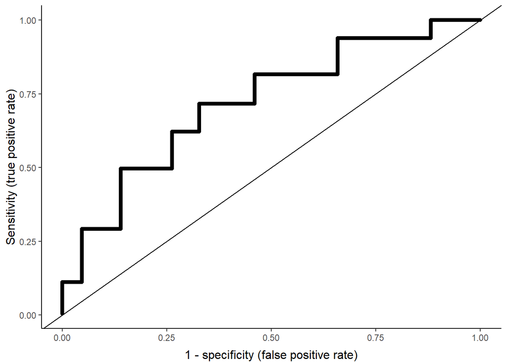

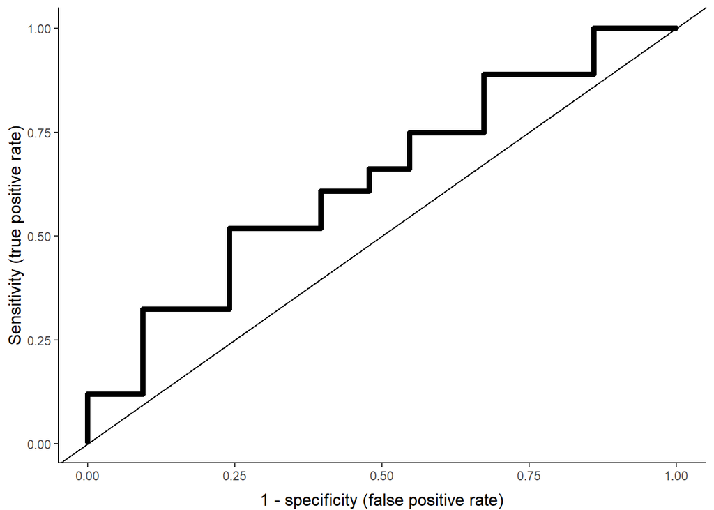

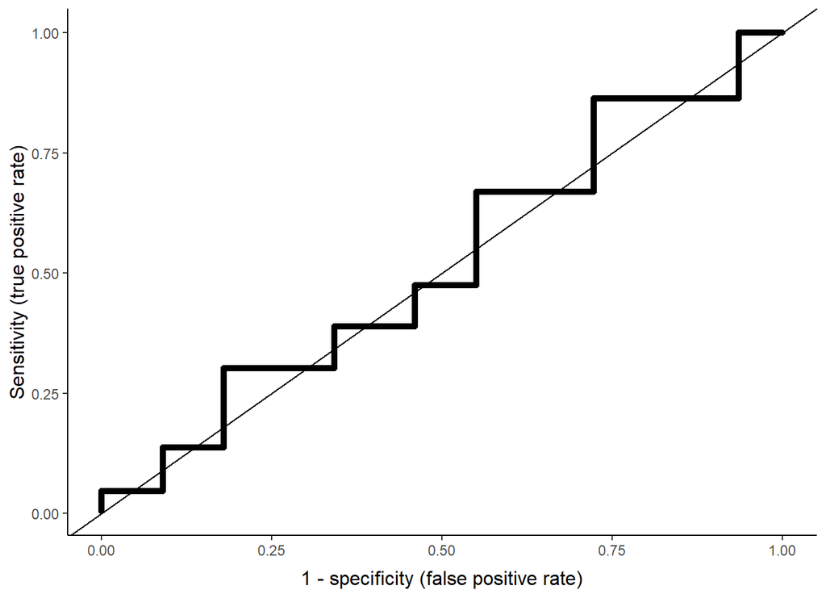

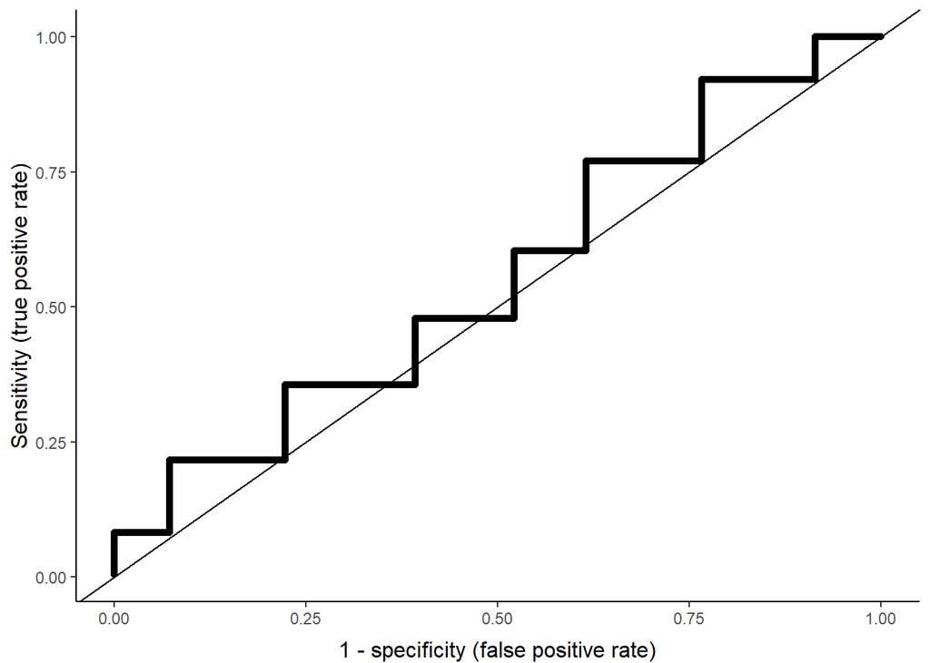

### AUC ~ Overall Proportion of Correct Responses

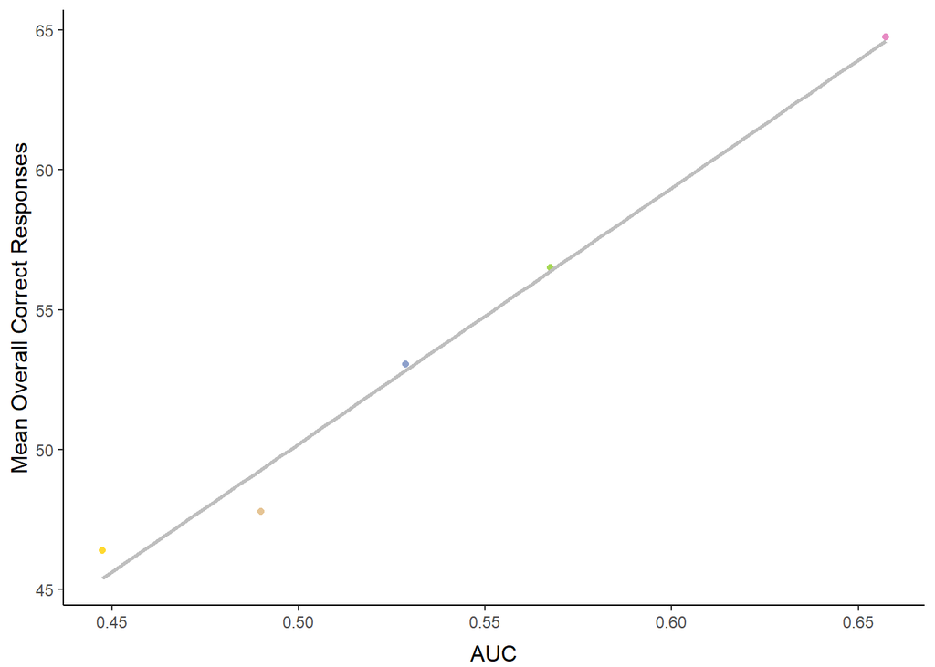

### AUC ~ Diff. Acoustic Feature

Is there a correlation between AUC for each item pair and the difference between the two values of the acoustic features (one value for adult and one for prodigy)?

```
## diff_Intensity_Mean_dB
##
##  Pearson's product-moment correlation
##
## data:  DATA_stimuli_pairs[[x_var]] and DATA_stimuli_pairs[, c(AUC)]
## t = 0.91235, df = 3, p-value = 0.4289
## alternative hypothesis: true correlation is not equal to 0
## 95 percent confidence interval:
##  -0.7068701  0.9554522
## sample estimates:
##      cor
## 0.466043
##
## diff_Intensity_SD_dB
##
##  Pearson's product-moment correlation
##
## data:  DATA_stimuli_pairs[[x_var]] and DATA_stimuli_pairs[, c(AUC)]
## t = -1.3716, df = 3, p-value = 0.2638
## alternative hypothesis: true correlation is not equal to 0
## 95 percent confidence interval:
##  -0.971156  0.578078
## sample estimates:
##        cor
## -0.6208166
##
## diff_Tempo_Mean
##
##  Pearson's product-moment correlation
##
## data:  DATA_stimuli_pairs[[x_var]] and DATA_stimuli_pairs[, c(AUC)]
## t = -1.4605, df = 3, p-value = 0.2403
## alternative hypothesis: true correlation is not equal to 0
## 95 percent confidence interval:
##  -0.9733291  0.5510279
## sample estimates:
##        cor
## -0.6446254
##
## diff_Tempo_SD
##
##  Pearson's product-moment correlation
##
## data:  DATA_stimuli_pairs[[x_var]] and DATA_stimuli_pairs[, c(AUC)]
## t = 1.1877, df = 3, p-value = 0.3204
## alternative hypothesis: true correlation is not equal to 0
## 95 percent confidence interval:
##  -0.6321360  0.9658757
## sample estimates:
##      cor
## 0.565538
```

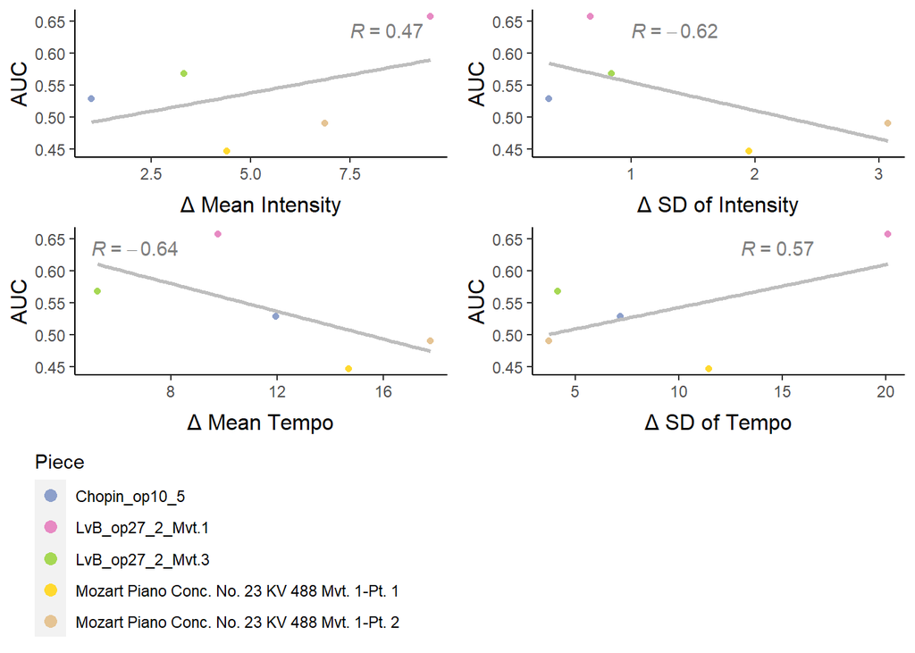

# IRT Measures and Acoustic Features

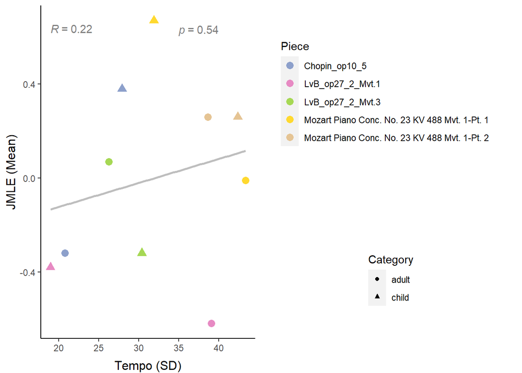

## IRT and AUC

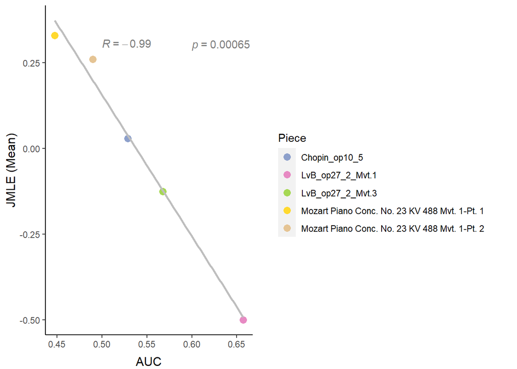